# All Interactions Are Wrong (?)

part 3: extent of the problem

psicostat

## Power for false positives

Fitting a model with two main (non-interacting) effects but an incorrect *link function* increases the risk of detecting a false interaction between them.

Is it a relevant problem?

The issue is fundamentally about **power**: the probability of detecting a false interaction is about equal to the power for that interaction if the *link function* were correctly specified.

## Example 1: log vs identity

Let’s consider this scenario ($\Delta \approx 50 ms$)

```r
set.seed(10)
library(ggplot2)
library(emmeans)
library(glmmTMB)

N = 5000
k = 20
id = rep(1:N,each=k*2)
group = rep(0:1,each=(N/2)*k*2)
cond = rep(0:1,each=k,times=N)

tau = 0.5
b0 = 1
b1 = 0.2
b2 = 0.35
shape = 10
scaleConstant = 200

rInt = rep(rnorm(N,0,tau),each=k*2)

X = b0 + b1*group + b2*cond + rInt
rt = rgamma(N*k*2, shape = shape, scale = scaleConstant*exp(X)/shape)

#(DELTA = scaleConstant*(exp(b0+b1+b2)-exp(b0+b2)) - scaleConstant*(exp(b0+b1)-exp(b0)) )

df = data.frame(id,group,cond,rt)
combin = paste(paste0("group",group),paste0("cond",cond))
df$combin = factor(combin)
df$group = as.factor(df$group)
df$cond = as.factor(df$cond)

fitGLog = glmmTMB(rt ~ group + cond + (1|id), family=Gamma(link="log"), data=df)

eff = data.frame(emmeans(fitGLog, specs="group", by="cond", type="response"))

ggplot(eff,aes(x=cond,y=response,group=group,color=group,shape=group,linetype=group))+
  geom_point(size=8)+
  geom_line(linewidth=1.5)+
  #geom_errorbar(aes(ymin=asymp.LCL,ymax=asymp.UCL),width=0)+
  theme(text=element_text(size=24))+
  ylab("rt")
```

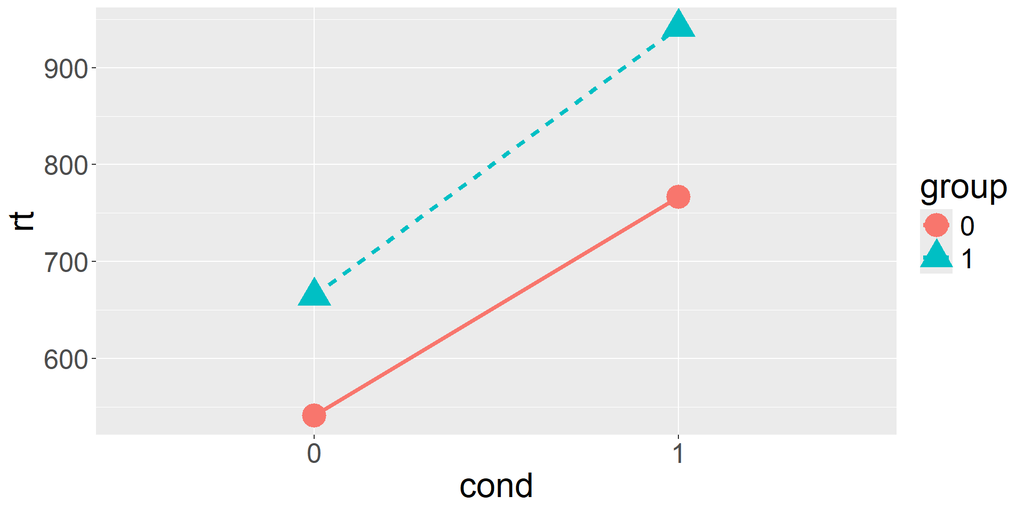

## Example 1: log vs identity

Let’s consider this scenario ($\Delta \approx 50 ms$)

```r
library(ggplot2)
ggplot(df)+
  geom_density(aes(x=rt,group=combin,color=combin),linewidth=2)+
  theme(text=element_text(size=24))+
  scale_color_manual(values=c("darkorange","coral3","darkturquoise","deepskyblue4"))+
  coord_cartesian(xlim=c(min(df$rt),quantile(df$rt,.9925)))
```

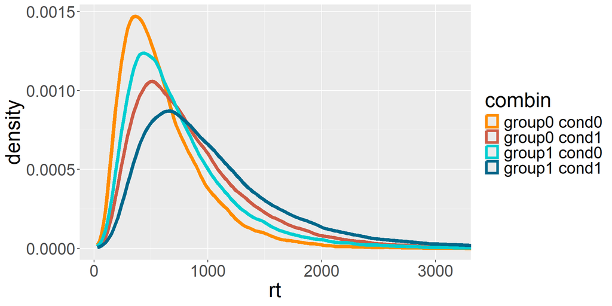

## Example 1: log vs identity

the fitted models are

1. *(correct)* `glmmTMB(rt ~ group * cond + (1|id), family=Gamma(link="log"), data=df)`,
2. *(wrong)* `glmmTMB(rt ~ group * cond + (1|id), family=Gamma(link="identity"), data=df)`

the interaction is NOT in the data generating process which is only `group + cond + (1|id)`; the difference between differences of $\Delta \approx 50 ms$ is entirely due to the exponential transformation of $X$

## Example 1: log vs identity

```r
N = 150
k = 20
id = rep(1:N,each=k*2)
group = rep(0:1,each=(N/2)*k*2)
cond = rep(0:1,each=k,times=N)
tau = 0.5
b0 = 1
b1 = 0.2
b2 = 0.35
shape = 10
scaleConstant = 200

niter = 1000
```

`N = 150` participants divided into 2 groups (between), all participants undergo 2 conditions (within) each with `k = 20` trials (total `k = 40` trials per participant), `ICC = 0.72`

## Example 1: `Gamma(link="log")`

```r
set.seed(10)
library(glmmTMB)

pvals = rep(NA,niter)

for(i in 1:niter){
  rInt = rep(rnorm(N,0,tau),each=k*2)

  X = b0 + b1*group + b2*cond + rInt
  rt = rgamma(N*k*2, shape = shape, scale = scaleConstant*exp(X)/shape)

  df = data.frame(id,group,cond,rt)
  df$group = as.factor(df$group)
  df$cond = as.factor(df$cond)

  fitGLog = glmmTMB(rt ~ group * cond + (1|id), family=Gamma(link="log"), data=df)
  pvals[i] = summary(fitGLog)$coefficients$cond["group1:cond1","Pr(>|z|)"]
}
```

`N = 150` participants divided into 2 groups (between), all participants undergo 2 conditions (within) each with `k = 20` trials (total `k = 40` trials per participant), `ICC = 0.72`

correct `link="log"`  
→ false positive interactions are **3.5%** (about ok)

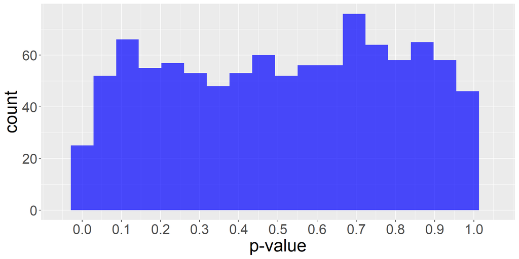

## Example 1: `Gamma(link="identity")`

```r
set.seed(10)
library(glmmTMB)

pvals = rep(NA,niter)

for(i in 1:niter){
  rInt = rep(rnorm(N,0,tau),each=k*2)

  X = b0 + b1*group + b2*cond + rInt
  rt = rgamma(N*k*2, shape = shape, scale = scaleConstant*exp(X)/shape)

  df = data.frame(id,group,cond,rt)
  df$group = as.factor(df$group)
  df$cond = as.factor(df$cond)

  fitGId = glmmTMB(rt ~ group * cond + (1|id), family=Gamma(link="identity"), data=df)
  pvals[i] = summary(fitGId)$coefficients$cond["group1:cond1","Pr(>|z|)"]
}
```

`N = 150` participants divided into 2 groups (between), all participants undergo 2 conditions (within) each with `k = 20` trials (total `k = 40` trials per participant), `ICC = 0.72`

incorrect `link="identity"`  
→ false positive interactions are **76.9%** (bad!)

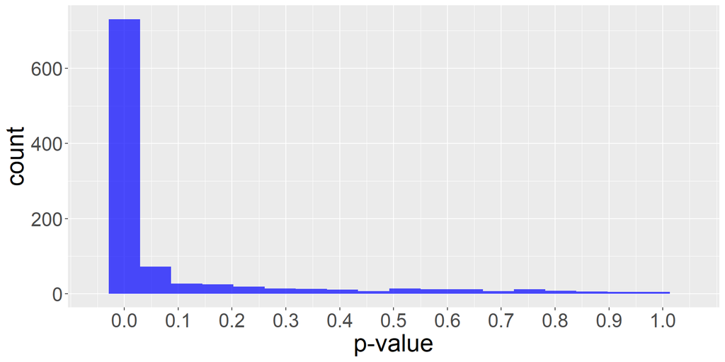

## Example 2: Probit vs Logit

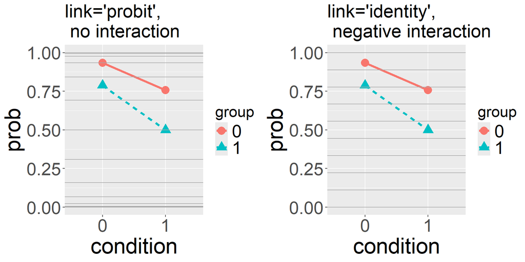

## Example 2: Probit vs Logit

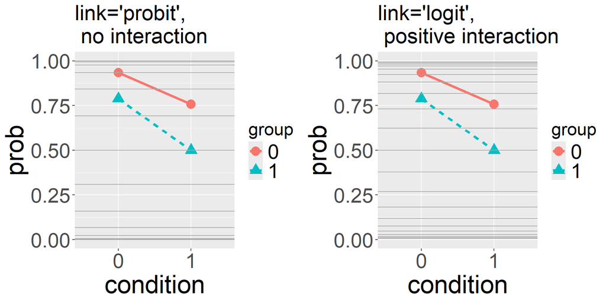

## Example 2: `binomial(link="probit")`

```r
set.seed(10)
trueLF = "probit"
usedLF = "probit"

N = 150
k = 20

b0 = 1.5
b1 = -0.7
b2 = -0.8

pvals = rep(NA,niter)
for(i in 1:niter){
  id = rep(1:N,each=k*2)
  rInt = rep(rnorm(N,0,1),each=k*2)
  group = rep(0:1,each=k*N)
  condition = rep(0:1,each=k,times=N)

  yLin = b0 + b1*group + b2*condition
  if(trueLF=="logit") yProb = plogis(yLin)
  if(trueLF=="probit") yProb = pnorm(yLin)
  y = rbinom(length(yLin),1,yProb)
  df = data.frame(y,id,group,condition)

  fit = glmmTMB(y ~ group*condition+(1|id), data=df, family=binomial(link=usedLF))
  pvals[i] = summary(fit)$coefficients$cond["group:condition","Pr(>|z|)"]
}
```

`N = 150` participants divided into 2 groups (between), all participants undergo 2 conditions (within) each with `k = 20` trials (total `k = 40` trials per participant), `ICC = 0.50`

correct `link="probit"`  
→ false positive interactions are **4.4%** (about ok)

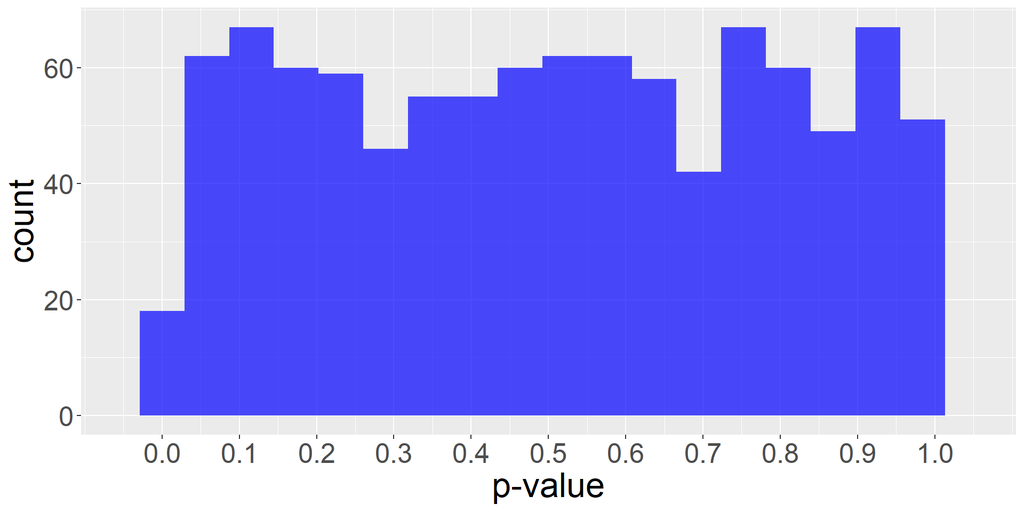

## Example 2: `binomial(link="logit")`

```r
set.seed(10)
trueLF = "probit"
usedLF = "logit"

N = 150
k = 20

b0 = 1.5
b1 = -0.7
b2 = -0.8

pvals = rep(NA,niter)
for(i in 1:niter){
  id = rep(1:N,each=k*2)
  rInt = rep(rnorm(N,0,1),each=k*2)
  group = rep(0:1,each=k*N)
  condition = rep(0:1,each=k,times=N)

  yLin = b0 + b1*group + b2*condition
  if(trueLF=="logit") yProb = plogis(yLin)
  if(trueLF=="probit") yProb = pnorm(yLin)
  y = rbinom(length(yLin),1,yProb)
  df = data.frame(y,id,group,condition)

  fit = glmmTMB(y ~ group*condition+(1|id), data=df, family=binomial(link=usedLF))
  pvals[i] = summary(fit)$coefficients$cond["group:condition","Pr(>|z|)"]
}
```

`N = 150` participants divided into 2 groups (between), all participants undergo 2 conditions (within) each with `k = 20` trials (total `k = 40` trials per participant), `ICC = 0.50`

incorrect `link="logit"`  
→ false positive interactions are **22.6%** (bad!)

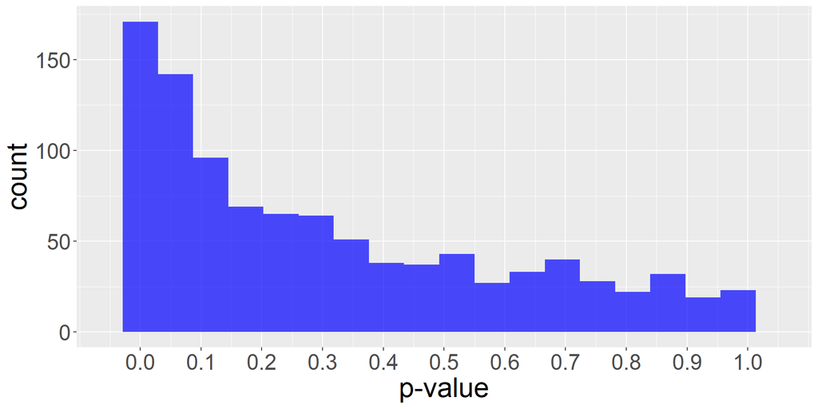

## Paradox - Probit vs Logit ?

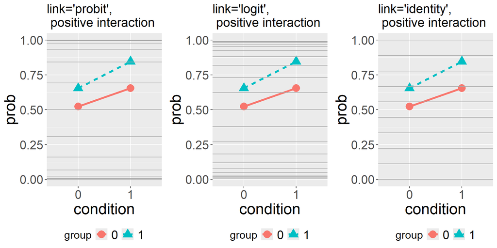

## Paradox - FORCED CHOICE !

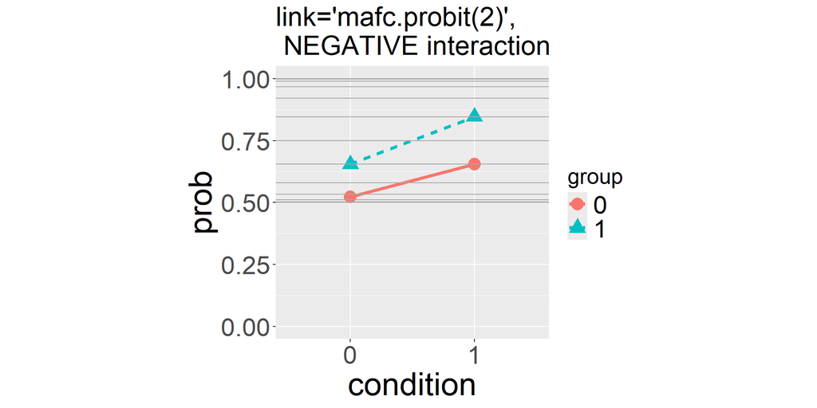

### When (inference) may NOT be a problem (with caution)

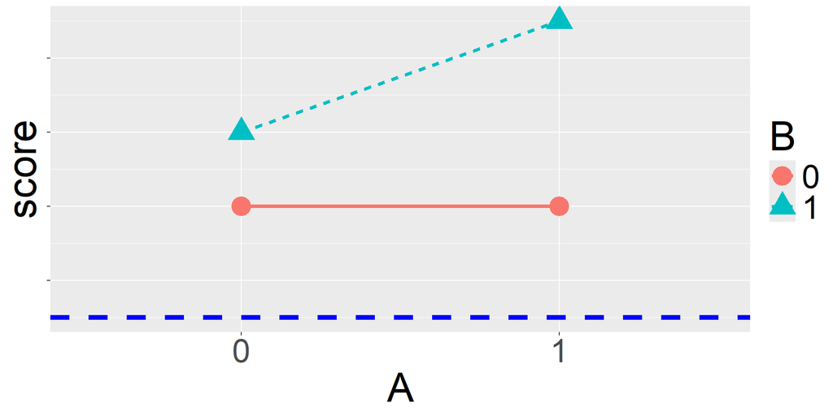

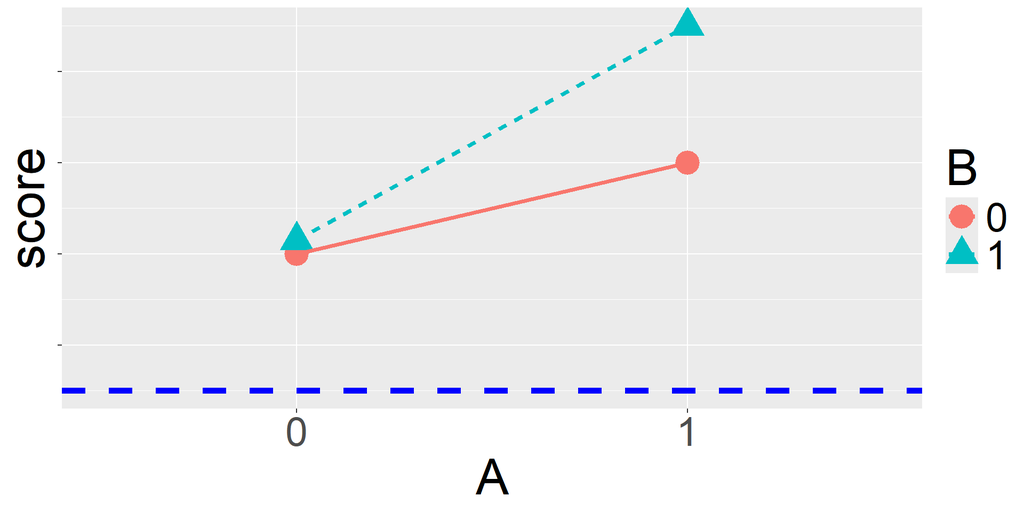

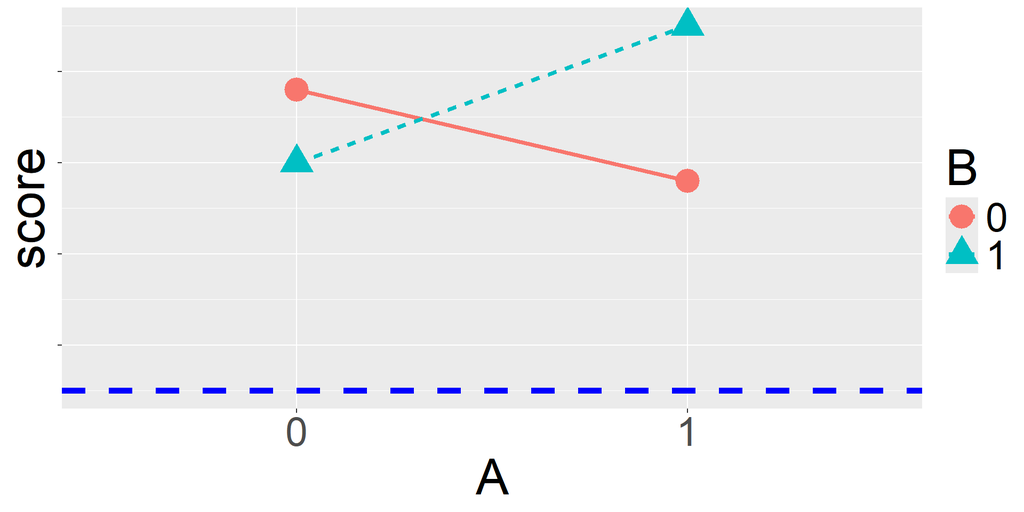

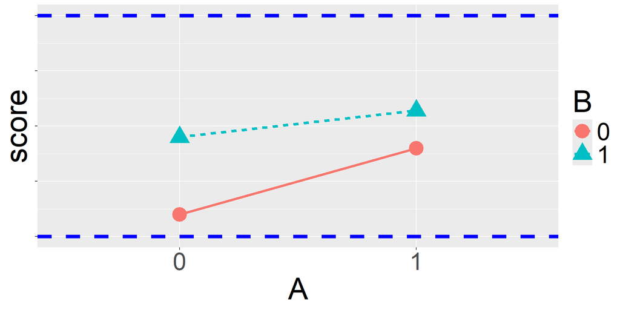